# chapter_4_assignment

Veronica Thompson

May 2, 2019

### 4.1 Why normal distributions are normal

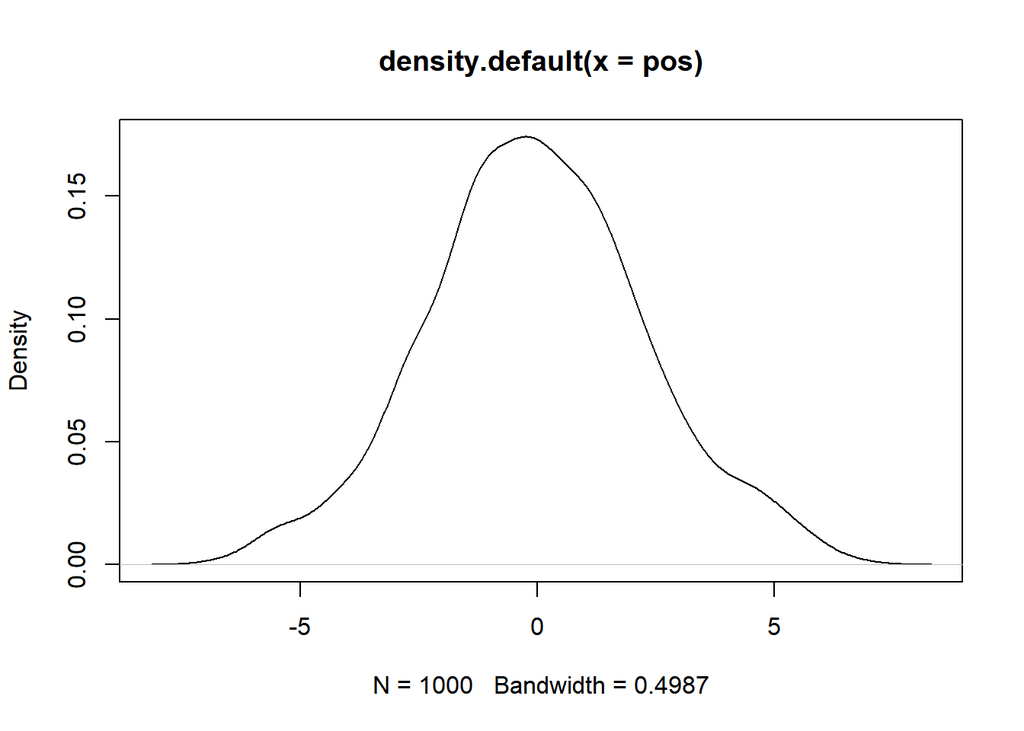

```r
pos = replicate(1000, sum(runif(16, -1, 1)))
plot(density(pos))
```

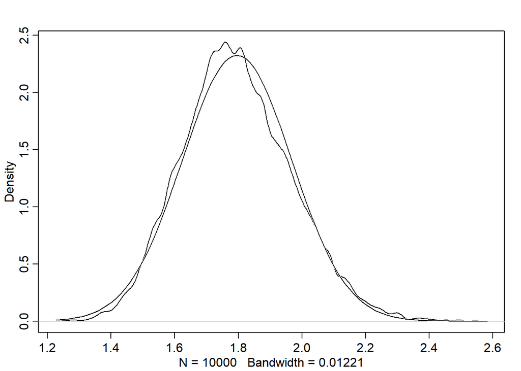

```r
growth <- replicate( 10000 , prod( 1 + runif(12,0,0.1) ) )
dens(growth, norm.comp = TRUE)
```

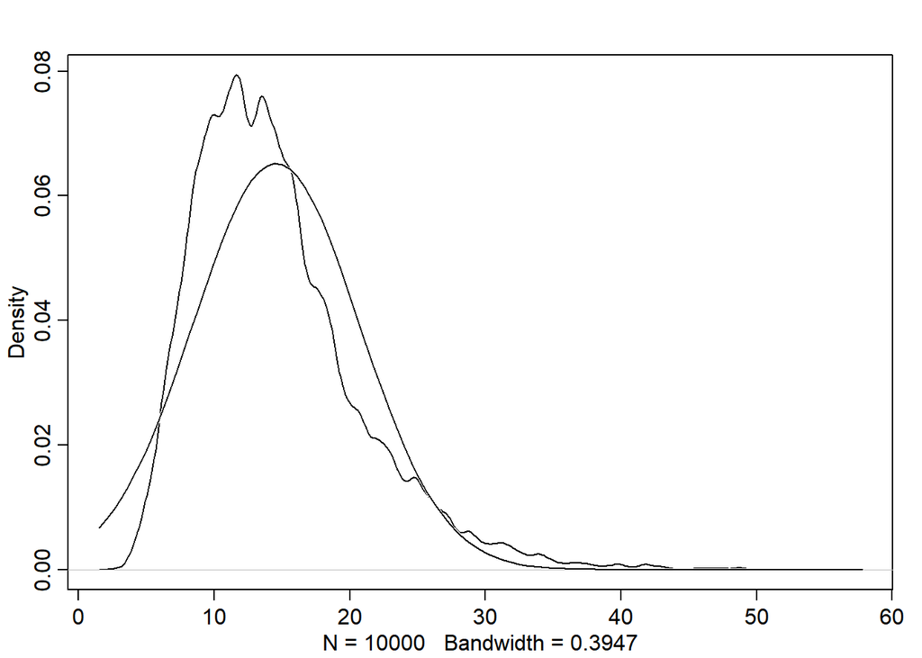

```r
big <- replicate( 10000 , prod( 1 + runif(12,0,0.5) ) )
small <- replicate( 10000 , prod( 1 + runif(12,0,0.01) ) )
dens(big, norm.comp = T)
```

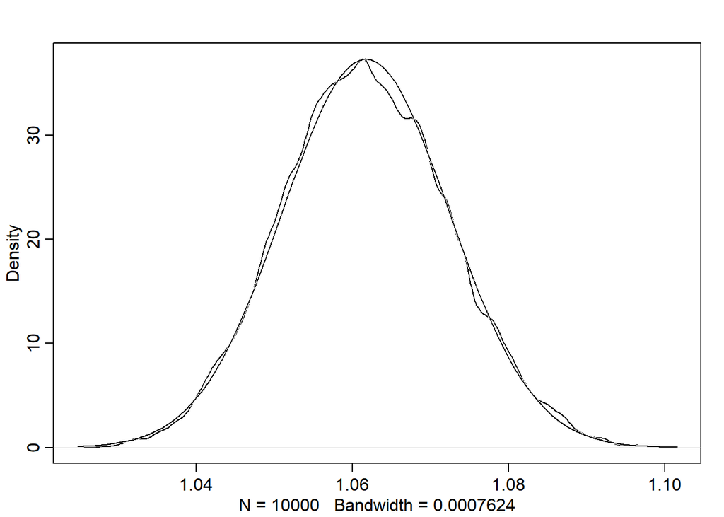

```r
dens(small, norm.comp = T) #small is more normal than big
```

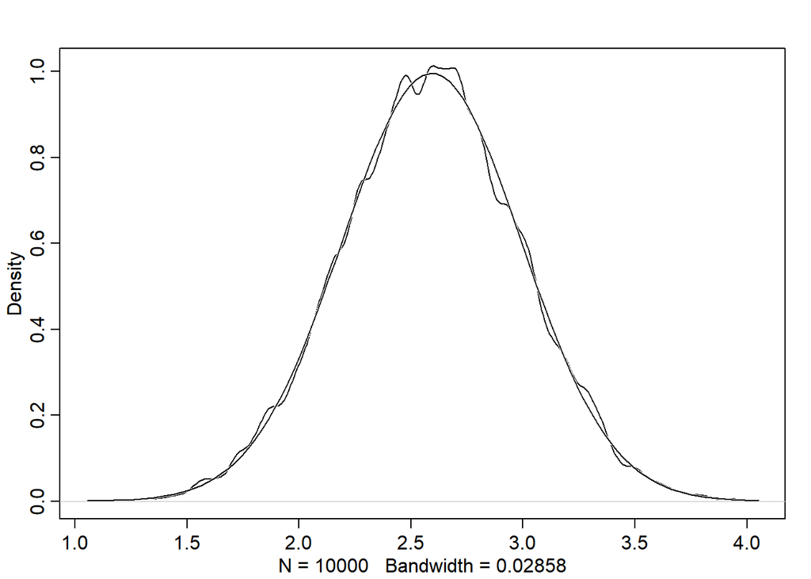

```r
log.big <- replicate( 10000 , log(prod(1 + runif(12,0,0.5))) )
dens(log.big, norm.comp = T)
```

### 4.3 A Gaussian model for height

requires:  
* a single measurment variable  
* two paaramenters to describe the distribution, mean and standard deviation * bayesian updating will help us score combinations of mean and standard deviation based on plausability based on data  
* goal: the posterior distribution will be a distribution of distributions  
(review this weirdness later)

load height data

```r
data("Howell1")
d = Howell1
str(d)
```

```
## 'data.frame':    544 obs. of  4 variables:
##  $ height: num  152 140 137 157 145 ...
##  $ weight: num  47.8 36.5 31.9 53 41.3 ...
##  $ age   : num  63 63 65 41 51 35 32 27 19 54 ...
##  $ male  : int  1 0 0 1 0 1 0 1 0 1 ...
```

another way to preview data

```r
precis(d)
```

```
##               mean         sd      5.5%     94.5%
## height 138.2635963 27.6024476 81.108550 165.73500
## weight  35.6106176 14.7191782  9.360721  54.50289
## age     29.3443934 20.7468882  1.000000  66.13500
## male     0.4724265  0.4996986  0.000000   1.00000
##                                                                                                       histogram
## height ▁▁▁▁▁▁▁▂▁▇▇▅▁
## weight ▁▂▃▂▂▂▂▅▇▇▃▂▁
## age                                    ▇▅▅▃▅▂▂▁▁
## male                           ▇▁▁▁▁▁▁▁▁▇
```

extract adults only and plot heights

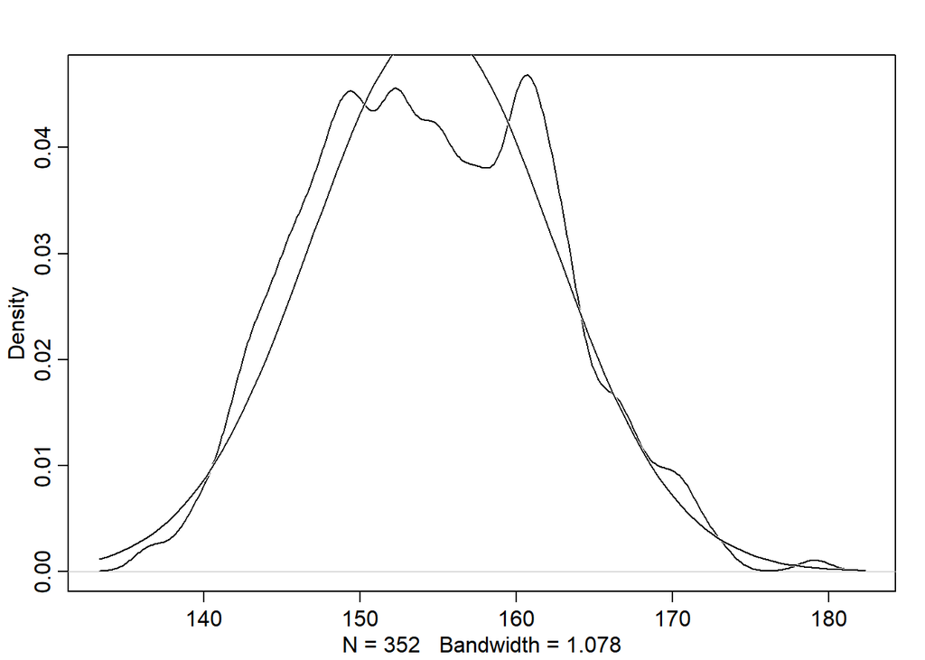

```r
d2 = d[d$age >= 18, ]
dens(d2$height, norm.comp = T)
```

looks normally distributed!

define heights of individuals as normally distributed with mean mu and standard dev, sigma  
*h*<sub>i</sub> ~ Normal(*mu*, *sigma*)

we will estimate paramters mu and sigma, so we must have prior Pr(mu, sigma) (joint prior)  
most of the time we can assume Pr(mu, sigma) = Pr(mu) Pr(sigma), so…

*h*<sub>i</sub> ~ Normal(*mu*, *sigma*) [likelihood]  
*mu* ~ Normal(178, 20) [mu prior, based on author’s height +- 40cm]  
*sigma* ~ Uniform(0,50) [sigma prior, flat prior, 95% of heights will be withing 100cm of mu]

plot the prior

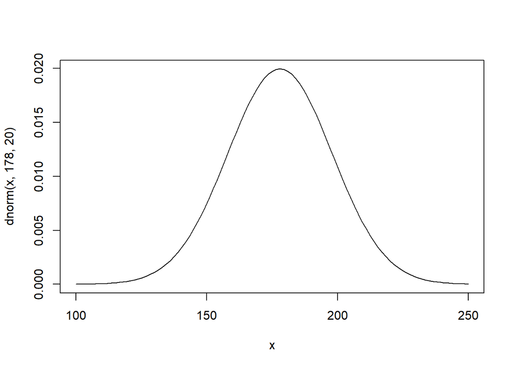

```r
curve( dnorm( x , 178 , 20 ) , from=100 , to=250 )
```

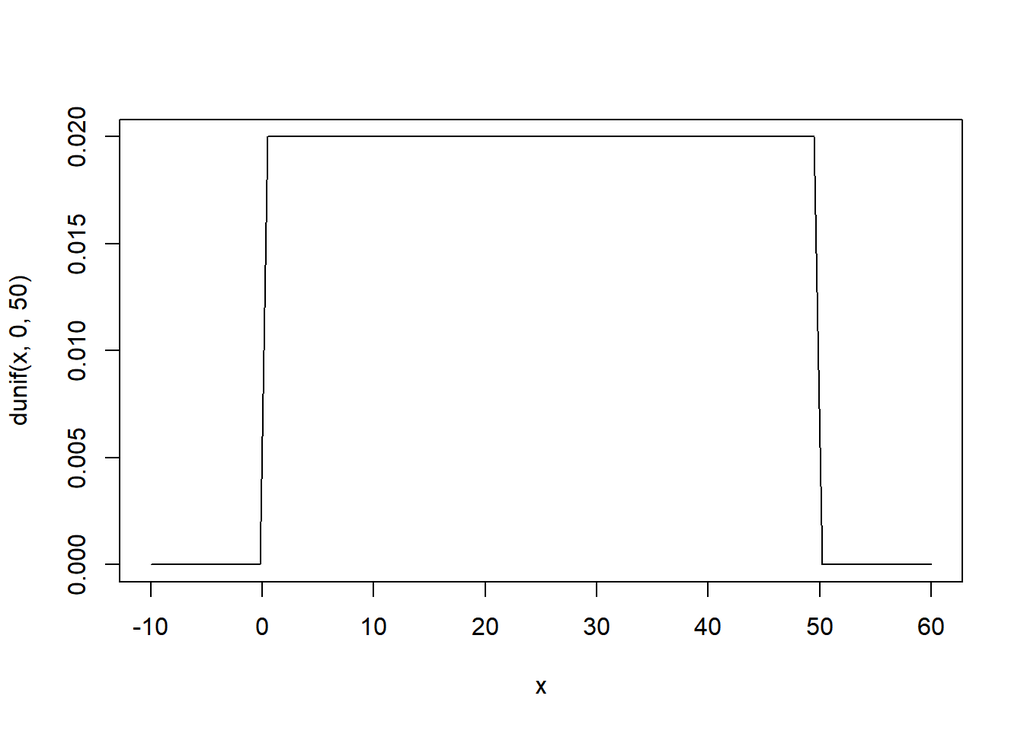

```r
curve( dunif( x , 0 , 50 ) , from=-10 , to=60 )
```

Next up, make a prior predictive simulation to show what your priors imply about height. This helps Id bad choices

Simulate heights by sampling from the prior (just like posterior sampling in Chap 3)

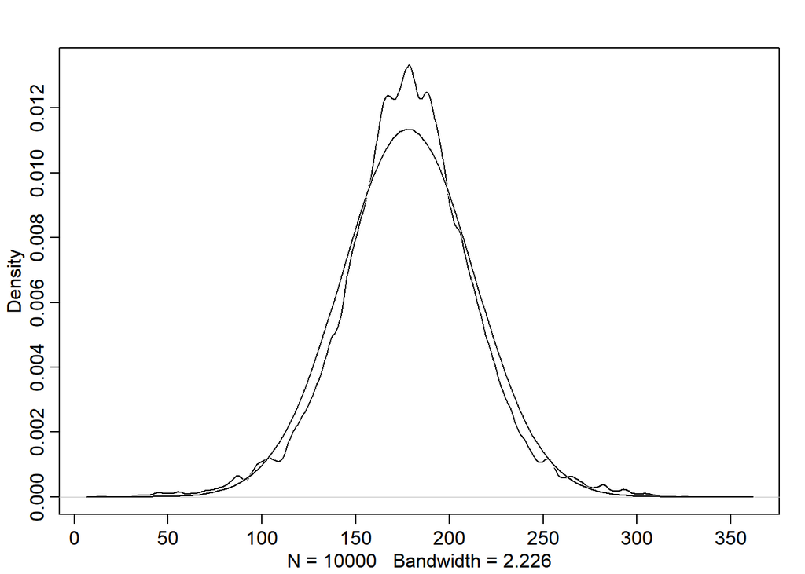

```r
sample_mu = rnorm(1e4, mean = 178, sd = 20)
sample_sigma = runif(1e4, min = 0, max = 50)
prior_h = rnorm(1e4, sample_mu, sample_sigma)
dens(prior_h, norm.comp = T)
```

test to see a more flat prior mu

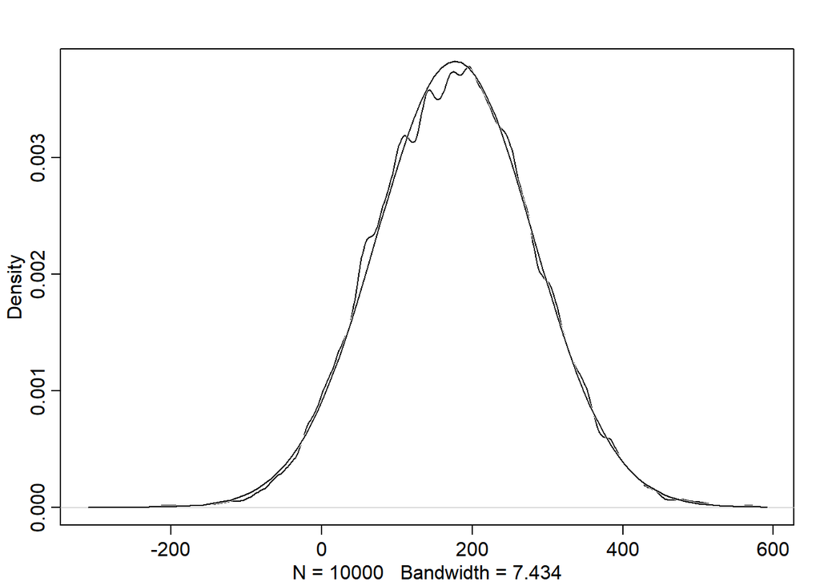

```r
sample_mu = rnorm(1e4, mean = 178, sd = 100)
prior_h = rnorm(1e4, sample_mu, sample_sigma)
dens(prior_h, norm.comp = T)
```

This is less useful beacsue it is not realistic. Some people will have negative height and more will be giants than we have observed in the human population

As an example, here is the full algorithm for the posterior distributuion. we will almost always use approximations because they cost less and are pretty accurate:

```r
mu.list <- seq( from=140, to=160 , length.out=200 )
sigma.list <- seq( from=4 , to=9 , length.out=200 )
post <- expand.grid( mu=mu.list , sigma=sigma.list )
post$LL <- sapply( 1:nrow(post) , function(i) sum( dnorm( d2$height , mean=post$mu[i] , sd=post$sigma[i] , log=TRUE ) ) )
post$prod <- post$LL + dnorm( post$mu , 178 , 20 , TRUE ) + dunif( post$sigma , 0 , 50 , TRUE )
post$prob <- exp( post$prod - max(post$prod) )
```

visualize contour map

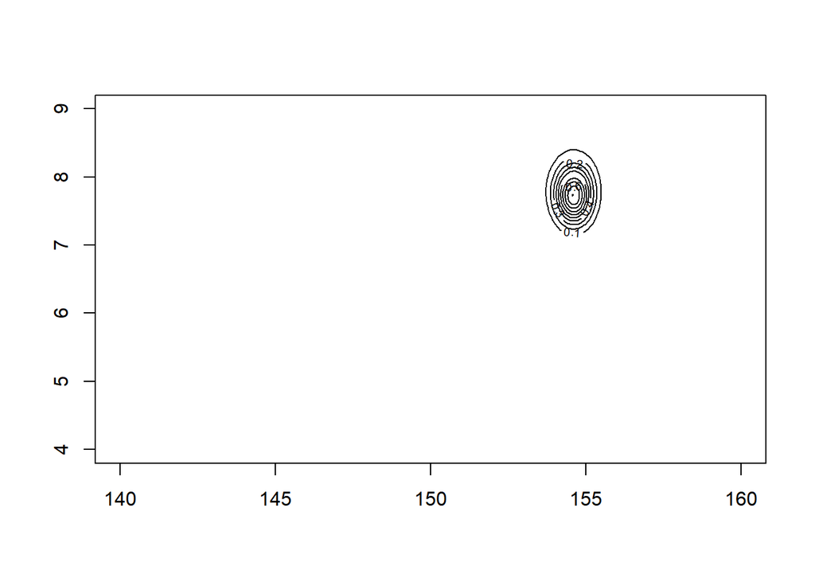

```r
contour_xyz( post$mu , post$sigma , post$prob )
```

visualize heat map

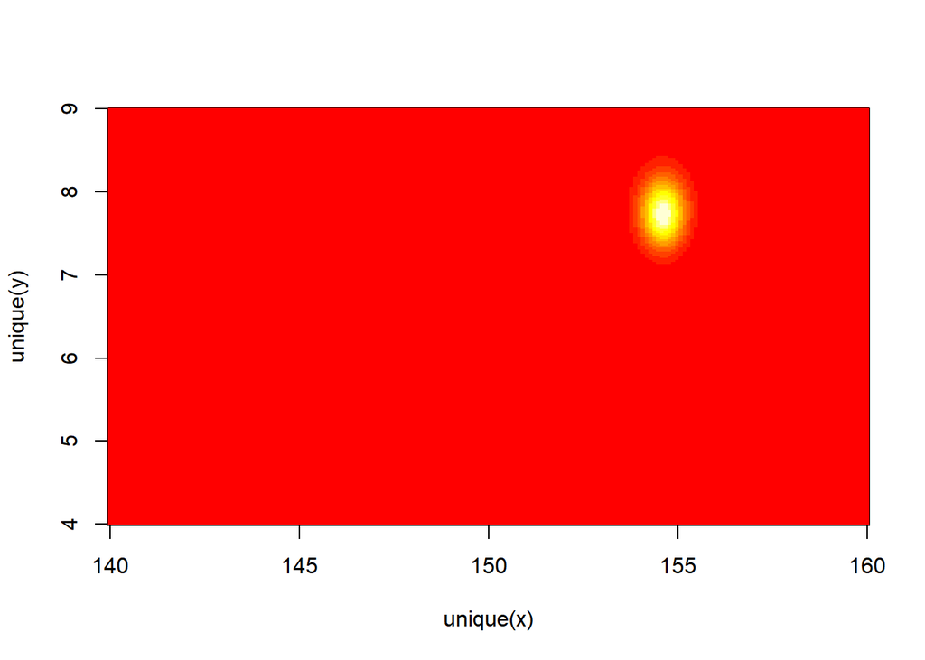

```r
image_xyz( post$mu , post$sigma , post$prob )
```

Based on priors we defined and height data mu is likely around 154-155 and sigma is around 7.5-8.1?

sampling the prior data  
because there are two parameters now we sample rows in prior then pull out the mu and sigma values

```r
sample.rows <- sample( 1:nrow(post) , size=1e4 , replace=TRUE , prob=post$prob )
sample.mu <- post$mu[ sample.rows ]
sample.sigma <- post$sigma[ sample.rows ]
```

visualize

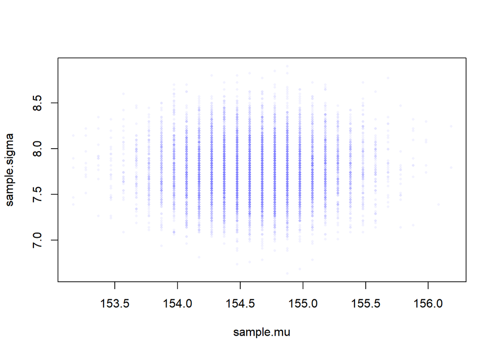

```r
plot( sample.mu , sample.sigma , cex=0.5 , pch=16 , col=col.alpha(rangi2,0.1) )
```

observe the distribution of each parameter

```r
HPDI(sample.mu)
```

```
##    |0.89    0.89|
## 153.8693 155.1759
```

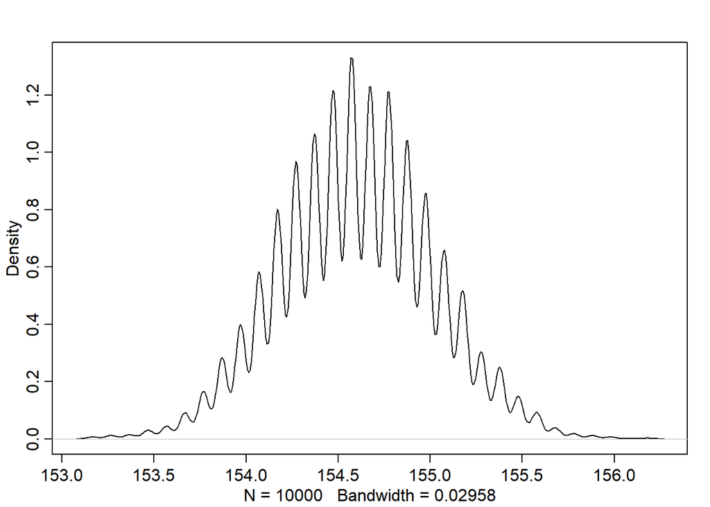

```r
dens(sample.mu)
```

```r
HPDI(sample.sigma)
```

```
##    |0.89    0.89|
## 7.266332 8.195980
```

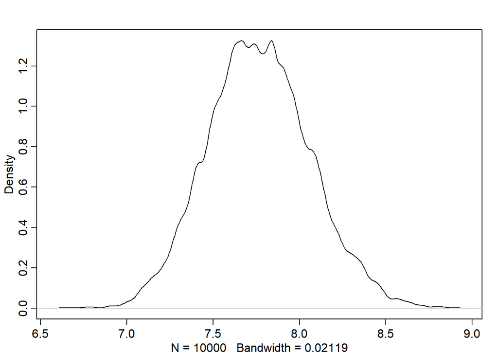

```r
dens(sample.sigma)
```

long tail to the right is common for sigma

next tool; quadratic approximation  
From the top now, load data and filter for adults

```r
data("Howell1")
d = Howell1
d2 = d[d$age >=18, ]
```

define the model as before, using R syntax  
*h*<sub>i</sub> ~ Normal(*mu*, *sigma*) [likelihood]  
*mu* ~ Normal(178, 20) [mu prior, based on author’s height +- 40cm]  
*sigma* ~ Uniform(0,50) [sigma prior, flat prior, 95% of heights will be withing 100cm of mu]

```r
flist = alist(
  height ~ dnorm(mu, sigma),
  mu ~ dnorm(178, 20),
  sigma ~ dunif(0, 50)
)
```

fit the model to the data in d2

```r
m4.1 = quap(flist, data = d2)
```

check out the posterior dist using precis

```r
precis(m4.1)
```

```
##             mean        sd       5.5%     94.5%
## mu    154.607122 0.4119917 153.948679 155.26556
## sigma   7.731277 0.2913808   7.265594   8.19696
```

the plausibility of each vlaue of mu after averaging over the palusibility of each value of sigma is given by a normal distribution with a mean of 154.61 and sd of .41. The 89% interval borders ate given

a more narrow prior for mu will make sd of posterior of mu much smaller.

sampling from a quap:  
a quadratic approximation of a posterior distribution with more than one parameter is a multi-dimensional  
gaussian distribution, so variance and covariance can help describe it

```r
vcov(m4.1)
```

```
##                 mu        sigma
## mu    0.1697371736 0.0002201803
## sigma 0.0002201803 0.0849027604
```

or broken down…

```r
diag( vcov( m4.1 ) )
```

```
##         mu      sigma
## 0.16973717 0.08490276
```

```r
cov2cor( vcov( m4.1 ) )
```

```
##                mu       sigma
## mu    1.000000000 0.001834126
## sigma 0.001834126 1.000000000
```

1’s in the matrix mean that each paramter is coorelated with itself. anything other than 1 is suspect  
low values at sigma, mu and mu, sigma indicate there is little coorelation between the two parameters, therefore knowing mu will not help find sigma or vice-versa.

to complete sampling, smaple vectors using rethinking package instead of single values on a gaussian dist.

```r
post <- extract.samples( m4.1 , n=1e4 )
head(post)
```

```
##         mu    sigma
## 1 154.6216 7.783772
## 2 154.2328 7.958043
## 3 154.4512 7.898852
## 4 154.3204 7.831103
## 5 154.4786 7.547839
## 6 153.8537 8.132035
```

### 4.4 adding a predictor

We will explore height v weight covariation

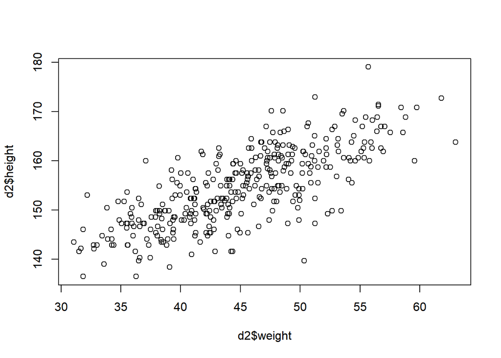

```r
plot( d2$height ~ d2$weight )
```

There seems to be predictive value here!

lets make a linear model  
we are asking “Consider all the lines that relate one variable to the other. Rank all of these lines by plausibility, given these data.”

our basic gaussian model  
*h*<sub>i</sub> ~ Normal(*mu*, *sigma*) [likelihood]  
*mu* ~ Normal(178, 20) [mu prior]  
*sigma* ~ Uniform(0,50) [sigma prior]

Build the porsterior approximation:

```r
#load data one more time for good luck
data("Howell1")
d = Howell1
d2 = d[d$age >= 18, ]

#define average weight based on the data
xbar <- mean(d2$weight)

# fit the model
m4.3 = quap(
  alist(
    height ~dnorm(mu, sigma),
    mu <- a + b*(weight  - xbar),
    a ~ dnorm(178, 20),
    b ~ dlnorm(0, 1),
    sigma ~ dunif(0, 50)
  ),
  data = d2 )
```

Practice problems **4E1.** In the model definition below, which line is the likelihood?  
**yi ∼ Normal(µ, σ)**  
µ ∼ Normal(0, 10)  
σ ∼ Uniform(0, 10)

**4E2.** In the model definition just above, how many parameters are in the posterior distribution?  
two!

**4E3.** Using the model definition above, write down the appropriate form of Bayes’ theorem that includes the proper likelihood and priors.  
ugh….

**4E4.** In the model definition below, which line is the linear model?  
yi ∼ Normal(µ, σ)  
**µi = α + βxi**  
α ∼ Normal(0, 10)  
β ∼ Normal(0, 1)  
σ ∼ Uniform(0, 10)

**4E5.** In the model definition just above, how many parameters are in the posterior distribution?  
three!

**4M1.** For the model definition below, simulate observed heights from the prior (not the posterior).  
yi ∼ Normal(µ, σ)  
µ ∼ Normal(0, 10)  
σ ∼ Uniform(0, 10)

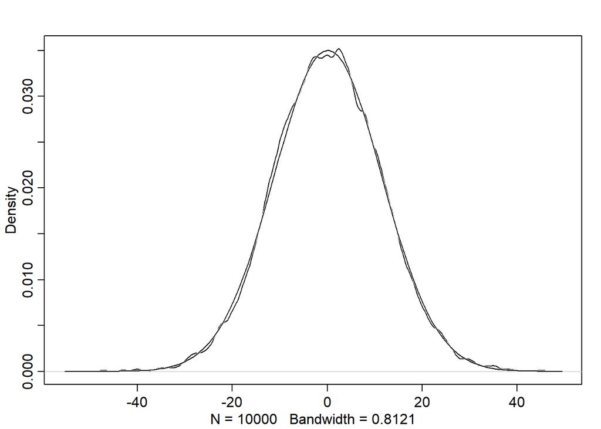

```r
sample_mu = rnorm(1e4, mean = 0, sd = 10)
sample_sigma = runif(1e4, min = 0, max = 10)
prior_height = rnorm(1e4, sample_mu, sample_sigma)
dens(prior_height, norm.comp = T)
```

**4M2.** Translate the model just above into a quap formula.

```r
m = alist(
  y ~ dnorm(mu, sigma),
  mu ~ dnorm(0, 10),
  sigma ~ dunif(0, 10))
```

**4M3.** Translate the quap model formula below into a mathematical model definition.

```r
flist <- alist(
  y ~ dnorm( mu , sigma ),
  mu <- a + b*x,
  a ~ dnorm( 0 , 50 ),
  b ~ dunif( 0 , 10 ),
  sigma ~ dunif( 0 , 50 ))
```